# Tooth Growth Data Analysis

Nicole Scott

## Exploratory Analysis and Data Summary

```r
library(datasets)
library(ggplot2)
str(ToothGrowth)
```

```
## 'data.frame':    60 obs. of  3 variables:
##  $ len : num  4.2 11.5 7.3 5.8 6.4 10 11.2 11.2 5.2 7 ...
##  $ supp: Factor w/ 2 levels "OJ","VC": 2 2 2 2 2 2 2 2 2 2 ...
##  $ dose: num  0.5 0.5 0.5 0.5 0.5 0.5 0.5 0.5 0.5 0.5 ...
```

```r
summary(ToothGrowth)
```

```
##       len        supp         dose
##  Min.   : 4.20   OJ:30   Min.   :0.500
##  1st Qu.:13.07   VC:30   1st Qu.:0.500
##  Median :19.25           Median :1.000
##  Mean   :18.81           Mean   :1.167
##  3rd Qu.:25.27           3rd Qu.:2.000
##  Max.   :33.90           Max.   :2.000
```

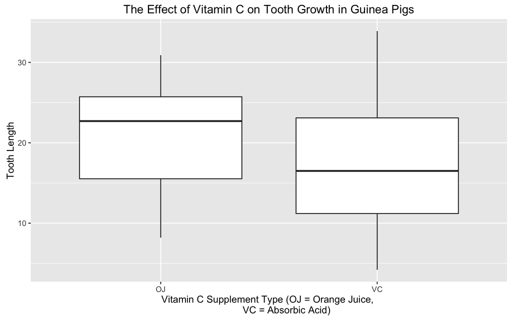

```r
ggplot(ToothGrowth) +
        geom_boxplot(aes(x = supp, y = len)) +
        ylab("Tooth Length") +
        xlab("Vitamin C Supplement Type (OJ = Orange Juice,
             VC = Absorbic Acid)") +
        ggtitle("The Effect of Vitamin C on Tooth Growth in Guinea Pigs")
```

This data set reports the length of odontoblasts (cells responsible for tooth growth) in 60 guinea pigs after different doses of Vitamin C given through orange juice or absorbic acid supplements (as described in the documentation). Using the str() function, it was found that the dataframe contained 3 variables for each of the 60 guinea pigs, “len” - a numeric variable for tooth length - “supp” - a factor indicating the type of supplement - and “dose” - a numeric variable corresponding to one of the 3 doses (0.5, 1, or 2 mg/day). Summary() was used to get an overview of the values in the dataset. The boxplot shows the difference between the two supplement types regardless of dose, with orange juice appearing to result in higher tooth length values.

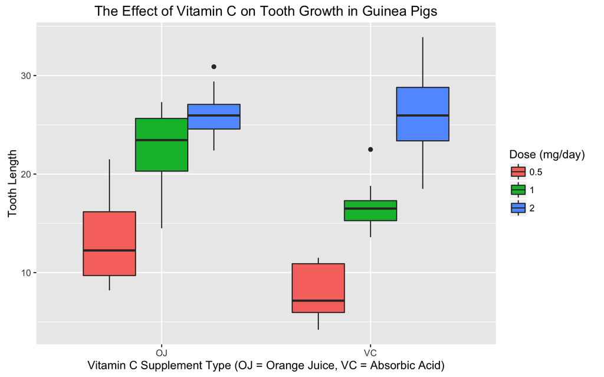

```r
ggplot(ToothGrowth) +
        geom_boxplot(aes(x = supp, y = len, fill = factor(dose)))+
        ylab("Tooth Length") +
        xlab("Vitamin C Supplement Type (OJ = Orange Juice, VC = Absorbic Acid)") +
        labs(fill = "Dose (mg/day)") +
        ggtitle("The Effect of Vitamin C on Tooth Growth in Guinea Pigs")
```

This plot further breaks down the previous boxplot by dose. It appears within each supplement type, tooth length increases with increased doseage. It also appears that orange juice also resulted in higher tooth length values within each dose, though that is less clear when the dose is 2 mg/day. These are the trends that will be investigated in the analysis of the data.

## Analysis

*For all comparisons in this analysis the test statistic used will be the mean. None of the comparisons will be considered paired as each observation corresponds to a different guinea pig.*

### Supplement Type Comparison

First to be examined is the hypothesis that orange juice supplements result in higher tooth length values overall (using values from all doses).

muo = average of OJ supplement group muv = average of absorbic acid group

H0: muo = muv Ha: muo > muv (or muo - muv > 0)

```r
t.test(len ~ supp, data = ToothGrowth, paired = FALSE, alternative = "greater",
       var.equal = FALSE)
```

```
##
##  Welch Two Sample t-test
##
## data:  len by supp
## t = 1.9153, df = 55.309, p-value = 0.03032
## alternative hypothesis: true difference in means is greater than 0
## 95 percent confidence interval:
##  0.4682687       Inf
## sample estimates:
## mean in group OJ mean in group VC
##         20.66333         16.96333
```

A one-sided test was used to test the hypothesis that the the mean of the OJ supplement group was higher than the mean of the absorbic acid group. The p-value indicates that the chance of observing the same difference in means if the population means of the two groups were the same is approximately 3%. With a reasonable alpha level of 5%, this indicates that the population estimated by the experiment does have a higher tooth length value with the Orange Juice supplement than absorbic acid. The variances were not assumed to be equal.  
*Note: this would not work in a two-sided test at the same alpha level, but as the alternative hypothesis did not include the orange juice mean being lower than the absorbic acid group this was not necessary.*

====================================

The next hypotheses examined is that increased dose groups result in a higher mean tooth length. Specifically the confidence interval for the middle dose for each supplement type will be compared to the higher and lower doses to determine if the patterns shown in the exploratory graphs are statistically significant.

### Orange Juice Group by Dose

muo.5 = mean orange juice 0.5 mg dose group

muo1 = mean orange juice 1 mg dose group

muo2 = mean orange juice 2 mg dose group

First the orange juice group is subsetted and each of the means calculated for later reference.

```r
library(dplyr)
ojgroup <- filter(ToothGrowth, supp == "OJ")
ojmeans <- summarise(group_by(ojgroup, dose), mean(len))
muo.5 <- as.numeric(ojmeans[1,2])
muo1 <- as.numeric(ojmeans[2,2])
muo2 <- as.numeric(ojmeans[3,2])
```

Then the 95% confidence interval is calculated for the middle (1 mg/day) dose.

```r
t.test(ojgroup$len[ojgroup$dose== 1], alternative = "two.sided")
```

```
##
##  One Sample t-test
##
## data:  ojgroup$len[ojgroup$dose == 1]
## t = 18.355, df = 9, p-value = 1.933e-08
## alternative hypothesis: true mean is not equal to 0
## 95 percent confidence interval:
##  19.90227 25.49773
## sample estimates:
## mean of x
##      22.7
```

The 95% confidence interval for the 1 mg/ day dose group is approximately 19.9 to 25.5. This means that observing a mean outside this range for any population with an equivalent mean to the population estimated by the 1 mg dose sample has a probability of 5% or lower. As the mean for the 0.5 mg group is 13.23 and the mean for the 2 mg group is 26.06, both of which lie outside the confidence interval of the 1 mg group, the differences observed between doses can be considered statistically significant with an alpha of 5%. This test does assume equal variance.

### Absorbic Acid Group by Dose

muv.5 = mean absorbic acid 0.5 mg dose group

muv1 = mean absorbic acid 1 mg dose group

muv2 = mean absorbic acid 2 mg dose group

First the absorbic acid group is subsetted and each of the means calculated for later reference.

```r
library(dplyr)
vcgroup <- filter(ToothGrowth, supp == "VC")
vcmeans <- summarise(group_by(vcgroup, dose), mean(len))
muv.5 <- as.numeric(vcmeans[1,2])
muv1 <- as.numeric(vcmeans[2,2])
muv2 <- as.numeric(vcmeans[3,2])
```

Then the 95% confidence interval is calculated for the middle (1 mg/day) dose.

```r
t.test(vcgroup$len[vcgroup$dose== 1], alternative = "two.sided")
```

```
##
##  One Sample t-test
##
## data:  vcgroup$len[vcgroup$dose == 1]
## t = 21.083, df = 9, p-value = 5.699e-09
## alternative hypothesis: true mean is not equal to 0
## 95 percent confidence interval:
##  14.97066 18.56934
## sample estimates:
## mean of x
##     16.77
```

The 95% confidence interval for the 1 mg/ day dose group is approximately 15.0 to 18.6. This means that observing a mean outside this range for any population with an equivalent mean to the population estimated by the 1 mg dose sample has a probability of 5% or lower. As the mean for the 0.5 mg group is 7.98 and the mean for the 2 mg group is 26.14, both of which lie outside the confidence interval of the 1 mg group, the differences observed between doses can be considered statistically significant with an alpha of 5%. This test does assume equal variance.

## Conclusions

With the assumptions described in the analysis section and a type I error rate of 5% (a 5% chance for each test that the null hypothesis was true), the data supports the hypotheses that 1) the orange juice supplement group population has a higher mean than the group given the absorbic acid supplement and 2) and 3) each supplement group showed an increasing tooth length value as the dose of the population increased.